# Cx4073 : Assignment 2

Arkar Min

U1721052K

### Marketing Campaign of a Bank

A certain Bank is conducting a marketing campaign to offer a specific *Term Deposit* to a large demography of targeted clients. The data provided in this exercise is related with direct marketing campaigns (phone calls) of the Bank. The classification goal is to predict if the targeted person will subscribe to the Term Deposit offered by the Bank. The Bank also wants to identify the top three variables that may affect the subscription chances of the targeted person, and they also want to know how to increase the chances for the person to subscribe to the Term Deposit.

### Analysis of Marketing Data

Import the CSV data file `assign2_MarketingData.csv` for analysis, and quickly check the structure of the data.

```r
marketData <- read.csv("assign2_MarketingData.csv", header = TRUE)
str(marketData)
```

```
## 'data.frame':    30000 obs. of  21 variables:
##  $ Age          : int  33 28 48 24 45 33 31 31 39 37 ...
##  $ Job          : Factor w/ 12 levels "admin","blue-collar",..: 7 8 5 9 1 1 8 8 1 1 ...
##  $ Marital      : Factor w/ 4 levels "divorced","married",..: 3 2 2 3 3 1 1 2 2 2 ...
##  $ Education    : Factor w/ 8 levels "basic4y","basic6y",..: 7 4 7 4 7 7 4 8 6 4 ...
##  $ Default      : Factor w/ 3 levels "no","unknown",..: 1 1 1 1 1 1 1 1 1 1 ...
##  $ Housing      : Factor w/ 3 levels "no","unknown",..: 2 3 3 1 2 1 3 3 1 3 ...
##  $ Loan         : Factor w/ 3 levels "no","unknown",..: 2 1 3 1 2 1 3 1 1 1 ...
##  $ Contact      : Factor w/ 2 levels "cellular","telephone": 2 1 2 1 1 2 1 1 1 2 ...
##  $ Month        : Factor w/ 10 levels "apr","aug","dec",..: 5 7 4 5 8 7 2 5 2 4 ...
##  $ Day          : Factor w/ 5 levels "fri","mon","thu",..: 1 1 3 4 4 1 4 4 1 3 ...
##  $ Duration     : int  38 237 154 253 133 279 242 98 306 29 ...
##  $ Campaign     : int  5 4 1 1 3 1 3 3 3 14 ...
##  $ PrevDays     : int  999 999 999 999 999 999 999 999 999 999 ...
##  $ Previous     : int  0 0 0 0 1 0 0 0 0 0 ...
##  $ PrevOutcome  : Factor w/ 3 levels "failure","nonexistent",..: 2 2 2 2 1 2 2 2 2 2 ...
##  $ EmpVarRate   : num  1.4 -1.8 1.4 -2.9 -3.4 1.1 1.4 -2.9 1.4 1.4 ...
##  $ ConPriceIndex: num  94.5 92.9 93.9 93 92.6 ...
##  $ ConConfIndex : num  -41.8 -46.2 -42.7 -40.8 -30.1 -36.4 -36.1 -40.8 -36.1 -42.7 ...
##  $ EuriborRate  : num  4.959 1.313 4.962 1.262 0.715 ...
##  $ NumEmp       : num  5228 5099 5228 5076 5018 ...
##  $ Subscribed   : Factor w/ 2 levels "no","yes": 1 1 1 1 1 1 1 1 1 1 ...
```

The following table summarizes the variables in the dataset. Check the data description carefully.

| Variable | Description | Type |
| --- | --- | --- |
| Age | Age of the person | Personal Profile |
| Job | Job Profile of the person | Personal Profile |
| Marital | Marital Status of the person | Personal Profile |
| Education | Highest Educational Qualification of the person | Personal Profile |
| Default | Does the person have Credit in Default? | Financial Profile |
| Housing | Does the person have a Housing Loan? | Financial Profile |
| Loan | Does the person have a Personal Loan? | Financial Profile |
| Contact | Type of Contact Number for Communication | Personal Profile |
| Month | Month of Year for the last contact with the person | Campaign Data |
| Day | Day of Week for the last contact with the person | Campaign Data |
| Duration | The duration of contact during the Last Contact | Campaign Data |
| Campaign | Number of contacts with the person during this Campaign | Campaign Data |
| PrevDays | Number of days from the last contact during the Previous Campaign | Campaign Data |
| Previous | Number of contacts with the person before this Campaign | Campaign Data |
| PrevOutcome | Outcome of previous Marketing Campaign for the person | Campaign Data |
| EmpVarRate | Employment Variation Rate in the person’s locality | Demographic Info |
| ConPriceIndex | Consumer Price Index (monthly) in the person’s locality | Demographic Info |
| ConConfIndex | Consumer Confidence Index (monthly) in the person’s locality | Demographic Info |
| EuriborRate | Euro Interbank Offered Rate (Euribor) for 3 months | Demographic Info |
| NumEmp | Number of Employees (quarterly) in the person’s locality | Demographic Info |
| Subscribed | Whether the person has Subscribed to a Term Deposit | Response/Target |

Value `unknown` in any categorical variable means the data is not available. `Duration = 0` means no communication during the last contact, or may be that there was *no* previous contact at all. `PrevDays = 999` means there was no previous contact with the person. The goal is to predict the response variable `Subscribed` for each person – that is, whether a person would subscribe to the *Term Deposit* being sold by the Bank.

#### Problem 1

Build an optimal tree-based classification model for `Subscribed` vs the **Personal Profile** and **Financial Profile** of a person. Check the relevant accuracy parameters of your model, and use it to predict `Subscribed` in the `assign2_MarketingPred.csv`.

- Identify the top three important variables in this case.
- Why are these important? Justify in terms of the Business.
- How would you influence `Subscribed` using these variables?

#### Problem 2

Build an optimal tree-based classification model for `Subscribed` vs **Personal Profile**, **Financial Profile**, and **Campaign Data** corresponding to a person. Check the relevant accuracy parameters of your model, and use it to predict `Subscribed` in the `assign2_MarketingPred.csv`.

- Identify the top three important variables in this case.
- Why are these important? Justify in terms of the Business.
- How would you influence `Subscribed` using these variables?

#### Problem 3

Build an optimal tree-based classification model for `Subscribed` vs all variables, **Personal Profile**, **Financial Profile**, **Campaign Data**, **Demographic Info** corresponding to a person. Check the relevant accuracy parameters of your model, and use it to predict `Subscribed` in the `assign2_MarketingPred.csv`.

- Identify the top three important variables in this case.
- Why are these important? Justify in terms of the Business.
- How would you influence `Subscribed` using these variables?

## Solution

```r
marketData <- read.csv("assign2_MarketingData.csv", header = TRUE)
predData <- read.csv('assign2_MarketingPred.csv', header = TRUE)
```

### Basic Data Exploration

```r
# Basic exploration
dim(marketData)      # dimension of the dataset
```

```
## [1] 30000    21
```

```r
names(marketData)    # labels of the columns/variables
```

```
##  [1] "Age"           "Job"           "Marital"       "Education"
##  [5] "Default"       "Housing"       "Loan"          "Contact"
##  [9] "Month"         "Day"           "Duration"      "Campaign"
## [13] "PrevDays"      "Previous"      "PrevOutcome"   "EmpVarRate"
## [17] "ConPriceIndex" "ConConfIndex"  "EuriborRate"   "NumEmp"
## [21] "Subscribed"
```

```r
str(marketData)      # structure of the dataset
```

```
## 'data.frame':    30000 obs. of  21 variables:
##  $ Age          : int  33 28 48 24 45 33 31 31 39 37 ...
##  $ Job          : Factor w/ 12 levels "admin","blue-collar",..: 7 8 5 9 1 1 8 8 1 1 ...
##  $ Marital      : Factor w/ 4 levels "divorced","married",..: 3 2 2 3 3 1 1 2 2 2 ...
##  $ Education    : Factor w/ 8 levels "basic4y","basic6y",..: 7 4 7 4 7 7 4 8 6 4 ...
##  $ Default      : Factor w/ 3 levels "no","unknown",..: 1 1 1 1 1 1 1 1 1 1 ...
##  $ Housing      : Factor w/ 3 levels "no","unknown",..: 2 3 3 1 2 1 3 3 1 3 ...
##  $ Loan         : Factor w/ 3 levels "no","unknown",..: 2 1 3 1 2 1 3 1 1 1 ...
##  $ Contact      : Factor w/ 2 levels "cellular","telephone": 2 1 2 1 1 2 1 1 1 2 ...
##  $ Month        : Factor w/ 10 levels "apr","aug","dec",..: 5 7 4 5 8 7 2 5 2 4 ...
##  $ Day          : Factor w/ 5 levels "fri","mon","thu",..: 1 1 3 4 4 1 4 4 1 3 ...
##  $ Duration     : int  38 237 154 253 133 279 242 98 306 29 ...
##  $ Campaign     : int  5 4 1 1 3 1 3 3 3 14 ...
##  $ PrevDays     : int  999 999 999 999 999 999 999 999 999 999 ...
##  $ Previous     : int  0 0 0 0 1 0 0 0 0 0 ...
##  $ PrevOutcome  : Factor w/ 3 levels "failure","nonexistent",..: 2 2 2 2 1 2 2 2 2 2 ...
##  $ EmpVarRate   : num  1.4 -1.8 1.4 -2.9 -3.4 1.1 1.4 -2.9 1.4 1.4 ...
##  $ ConPriceIndex: num  94.5 92.9 93.9 93 92.6 ...
##  $ ConConfIndex : num  -41.8 -46.2 -42.7 -40.8 -30.1 -36.4 -36.1 -40.8 -36.1 -42.7 ...
##  $ EuriborRate  : num  4.959 1.313 4.962 1.262 0.715 ...
##  $ NumEmp       : num  5228 5099 5228 5076 5018 ...
##  $ Subscribed   : Factor w/ 2 levels "no","yes": 1 1 1 1 1 1 1 1 1 1 ...
```

```r
head(marketData)     # first few (6) rows of the data
```

```
##   Age           Job  Marital  Education Default Housing    Loan   Contact
## 1  33 self-employed   single university      no unknown unknown telephone
## 2  28      services  married highschool      no     yes      no  cellular
## 3  48    management  married university      no     yes     yes telephone
## 4  24       student   single highschool      no      no      no  cellular
## 5  45         admin   single university      no unknown unknown  cellular
## 6  33         admin divorced university      no      no      no telephone
##   Month Day Duration Campaign PrevDays Previous PrevOutcome EmpVarRate
## 1   jun fri       38        5      999        0 nonexistent        1.4
## 2   may fri      237        4      999        0 nonexistent       -1.8
## 3   jul thu      154        1      999        0 nonexistent        1.4
## 4   jun tue      253        1      999        0 nonexistent       -2.9
## 5   nov tue      133        3      999        1     failure       -3.4
## 6   may fri      279        1      999        0 nonexistent        1.1
##   ConPriceIndex ConConfIndex EuriborRate NumEmp Subscribed
## 1        94.465        -41.8       4.959 5228.1         no
## 2        92.893        -46.2       1.313 5099.1         no
## 3        93.918        -42.7       4.962 5228.1         no
## 4        92.963        -40.8       1.262 5076.2         no
## 5        92.649        -30.1       0.715 5017.5         no
## 6        93.994        -36.4       4.855 5191.0         no
```

```r
tail(marketData)     # last few (6) rows of the data
```

```
##       Age          Job Marital    Education Default Housing Loan   Contact
## 29995  29        admin  single   highschool      no     yes  yes  cellular
## 29996  44  blue-collar married professional unknown      no   no  cellular
## 29997  45        admin married   highschool      no      no   no telephone
## 29998  23   technician married professional      no     yes  yes  cellular
## 29999  86      retired married      unknown unknown     yes  yes  cellular
## 30000  44 entrepreneur married   university      no     yes   no  cellular
##       Month Day Duration Campaign PrevDays Previous PrevOutcome EmpVarRate
## 29995   mar mon      257        1      999        0 nonexistent       -1.8
## 29996   jul tue      156       20      999        0 nonexistent        1.4
## 29997   jun fri       48        5      999        0 nonexistent        1.4
## 29998   oct thu      408        2      999        0 nonexistent       -3.4
## 29999   sep tue      211        1        7        4     success       -1.1
## 30000   apr fri     1034        2      999        0 nonexistent       -1.8
##       ConPriceIndex ConConfIndex EuriborRate NumEmp Subscribed
## 29995        93.369        -34.8       0.646 5008.7        yes
## 29996        93.918        -42.7       4.961 5228.1         no
## 29997        94.465        -41.8       4.967 5228.1         no
## 29998        92.431        -26.9       0.722 5017.5         no
## 29999        94.199        -37.5       0.877 4963.6        yes
## 30000        93.075        -47.1       1.405 5099.1         no
```

There are total of 30,000 data and 21 types of variables. Age, Duration, Campaign, PrevDays, Previous, EmpVarRate, ConPriceIndex, ConConfIndex, EuriborRate, NumEmp looks like they have continuous values but need to plot graph to confirm that. For now, 10 features out of 20 (Since Subscribed is a target) clearly have categorical values.

```r
summary(marketData)  # summary statistics for all variables
```

```
##       Age                 Job           Marital             Education
##  Min.   :17.00   admin      :7636   divorced: 3349   university  :8841
##  1st Qu.:32.00   blue-collar:6723   married :18166   highschool  :6897
##  Median :38.00   technician :4899   single  : 8431   basic9y     :4438
##  Mean   :40.03   services   :2893   unknown :   54   professional:3819
##  3rd Qu.:47.00   management :2089                    basic4y     :3069
##  Max.   :98.00   retired    :1261                    basic6y     :1655
##                  (Other)    :4499                    (Other)     :1281
##     Default         Housing           Loan            Contact
##  no     :23739   no     :13567   no     :24706   cellular :19094
##  unknown: 6259   unknown:  717   unknown:  717   telephone:10906
##  yes    :    2   yes    :15716   yes    : 4577
##
##
##
##
##      Month       Day          Duration         Campaign
##  may    :9988   fri:5739   Min.   :   0.0   Min.   : 1.000
##  jul    :5299   mon:6190   1st Qu.: 103.0   1st Qu.: 1.000
##  aug    :4479   thu:6255   Median : 179.0   Median : 2.000
##  jun    :3793   tue:5918   Mean   : 258.1   Mean   : 2.544
##  nov    :3037   wed:5898   3rd Qu.: 320.0   3rd Qu.: 3.000
##  apr    :1911              Max.   :4918.0   Max.   :56.000
##  (Other):1493
##     PrevDays        Previous           PrevOutcome      EmpVarRate
##  Min.   :  0.0   Min.   :0.0000   failure    : 3073   Min.   :-3.40000
##  1st Qu.:999.0   1st Qu.:0.0000   nonexistent:25942   1st Qu.:-1.80000
##  Median :999.0   Median :0.0000   success    :  985   Median : 1.10000
##  Mean   :962.8   Mean   :0.1707                       Mean   : 0.08312
##  3rd Qu.:999.0   3rd Qu.:0.0000                       3rd Qu.: 1.40000
##  Max.   :999.0   Max.   :6.0000                       Max.   : 1.40000
##
##  ConPriceIndex    ConConfIndex    EuriborRate        NumEmp
##  Min.   :92.20   Min.   :-50.8   Min.   :0.634   Min.   :4964
##  1st Qu.:93.08   1st Qu.:-42.7   1st Qu.:1.344   1st Qu.:5099
##  Median :93.75   Median :-41.8   Median :4.857   Median :5191
##  Mean   :93.57   Mean   :-40.5   Mean   :3.625   Mean   :5167
##  3rd Qu.:93.99   3rd Qu.:-36.4   3rd Qu.:4.961   3rd Qu.:5228
##  Max.   :94.77   Max.   :-26.9   Max.   :5.045   Max.   :5228
##
##  Subscribed
##  no :26603
##  yes: 3397
##
##
##
##
##
```

Age having maximumn age of 98 is interesting. Wouldn’t they be too old to target? Total unknown values of Housing and Loan are similiar. The difference between Maximum value and 3rd quadrant values of Duration and Campaign is too big. Campaign, PrevDays, Previous are suspected to be categorical values.

Another interesting fact is (Other) type in features that has categorical value. Seems like R put types that have small value compared to the rest in the (Other) type. For Example, first row of Job is self-employment but it is not mentioned in the Summary Data of Job.

Let see the histogram of suspected categorical value.

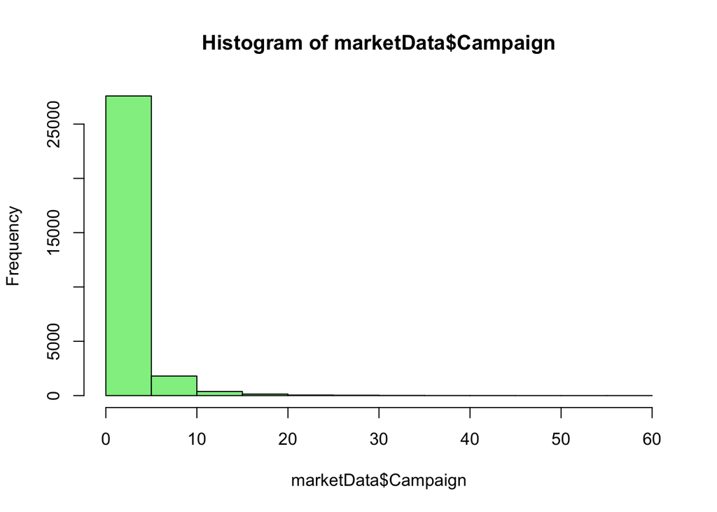

```r
hist(marketData$Campaign,col='lightgreen')
```

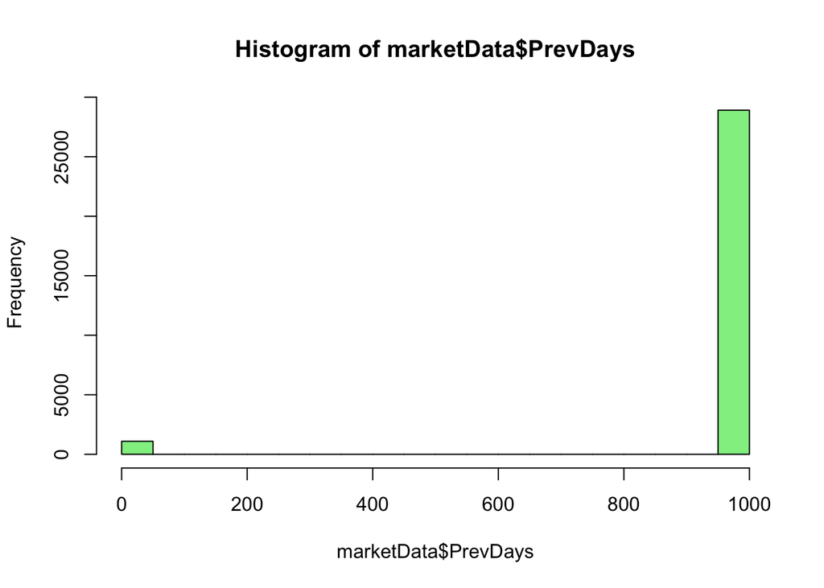

```r
hist(marketData$PrevDays,col='lightgreen')
```

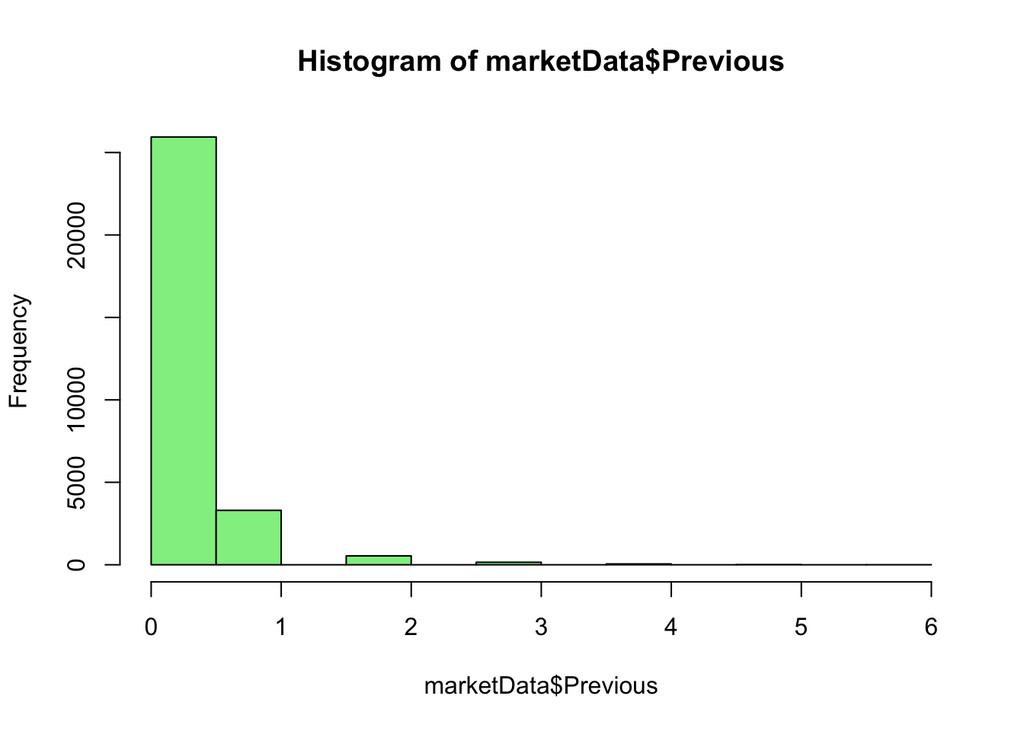

```r
hist(marketData$Previous,col='lightgreen')
```

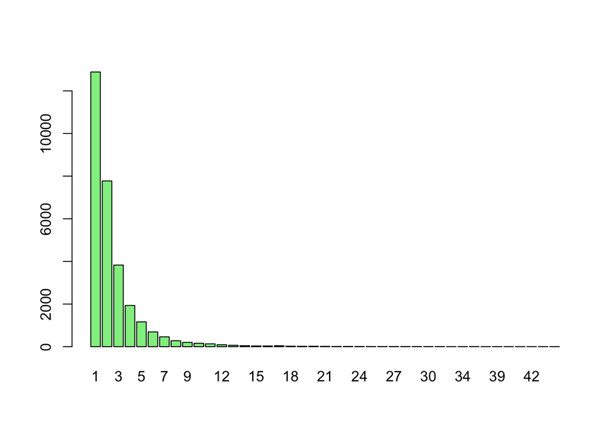

```r
campaign <- as.factor(marketData$Campaign)
barplot(table(campaign), col = 'lightgreen')
```

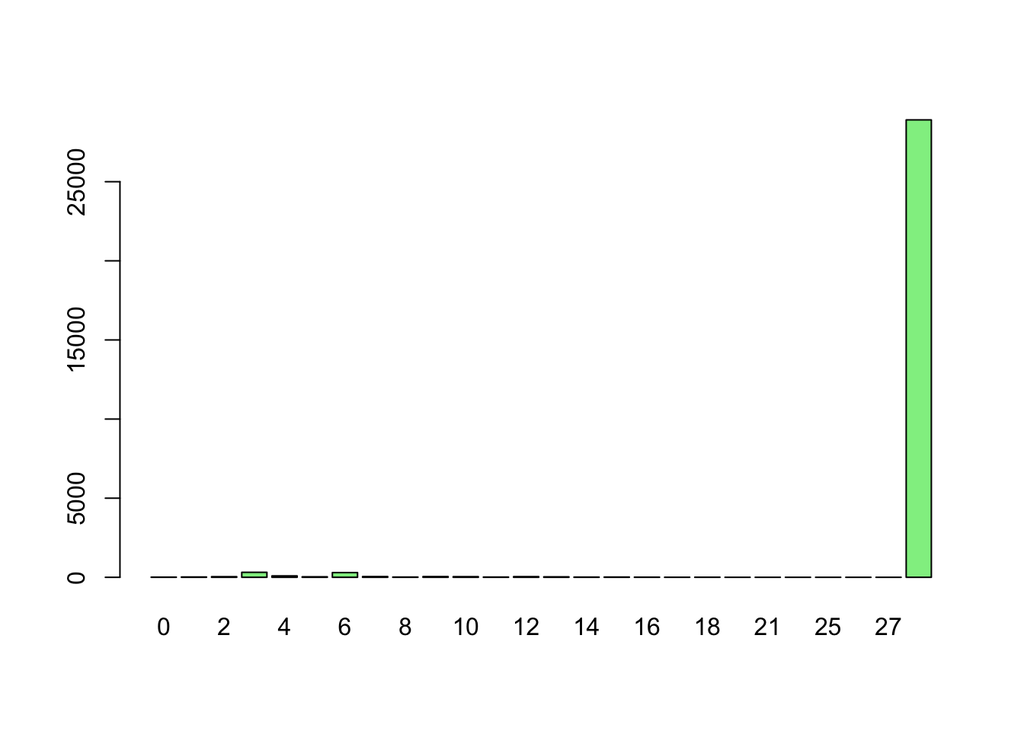

```r
prevdays <- as.factor(marketData$PrevDays)
barplot(table(prevdays), col = 'lightgreen')
```

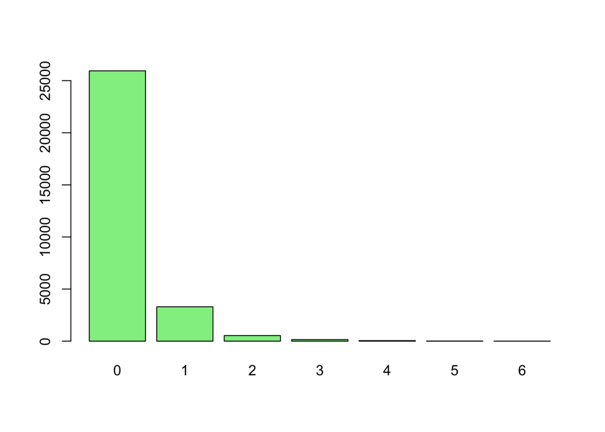

```r
previous <- as.factor(marketData$Previous)
barplot(table(previous), col = 'lightgreen')
```

It is hard to say Campaign as categorical value but there is high density of data in the early stage of data then the rest. It is the same for previous day. There are high density of data at 999.

For previous, we can say it is a categorical value. Data is spread across 0 to 6. Though there is a high density of data at 0.

So, based on the early exploration, we can say that there are 11 categorical features and 9 continuous features.

Let see how Subscribed looks like in plot.

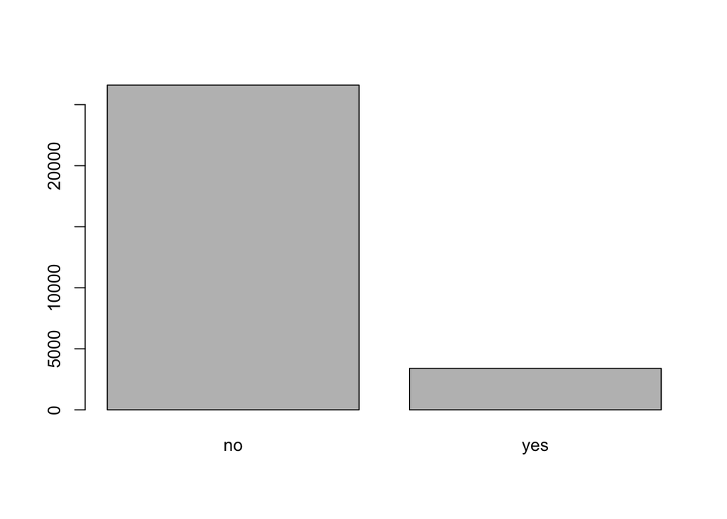

```r
plot(marketData$Subscribed)
```

Data is unbalanced. There are a lot of data in “no”" values compared to “yes”. That can cerate a huge bias in the model.

Now, the relation between those features against target value. Features that have categorical value will be plotted first.

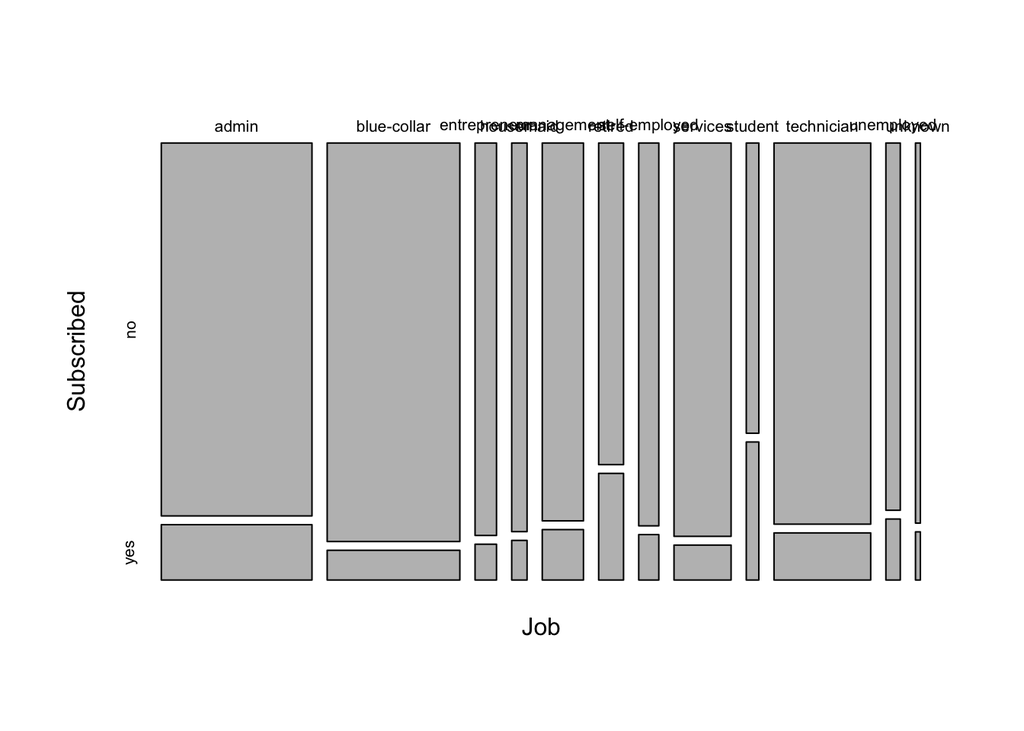

```r
mosaicplot(table(marketData$Job, marketData$Subscribed), main="", ylab="Subscribed", xlab="Job") #matter a lot
```

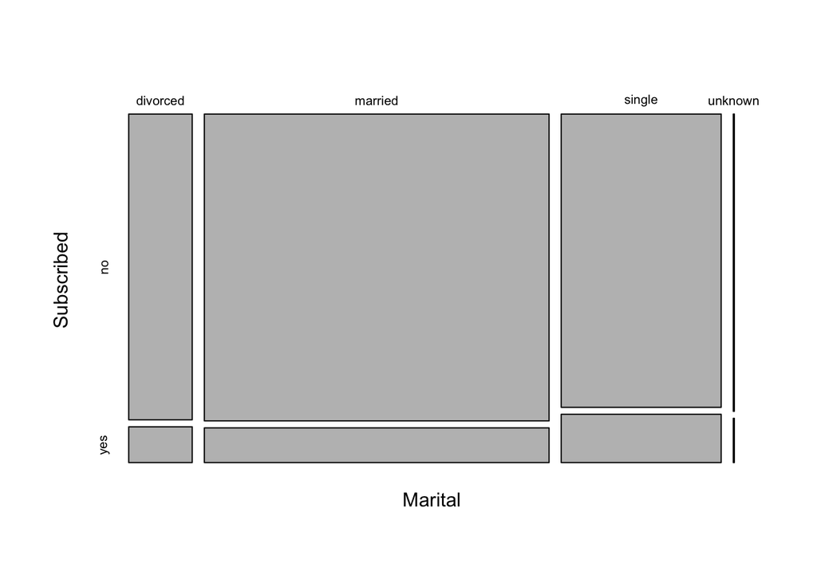

```r
mosaicplot(table(marketData$Marital, marketData$Subscribed), main="", ylab="Subscribed", xlab="Marital") #does not matter
```

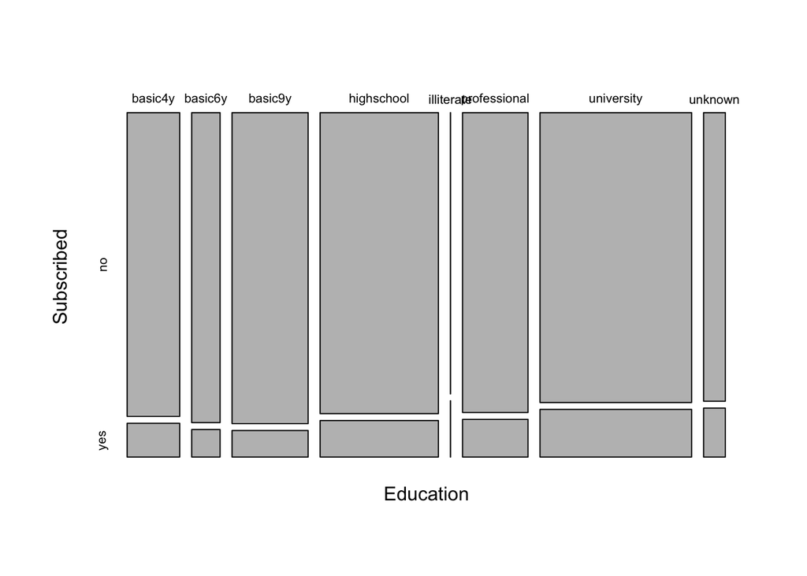

```r
mosaicplot(table(marketData$Education, marketData$Subscribed), main="", ylab="Subscribed", xlab="Education") #no
```

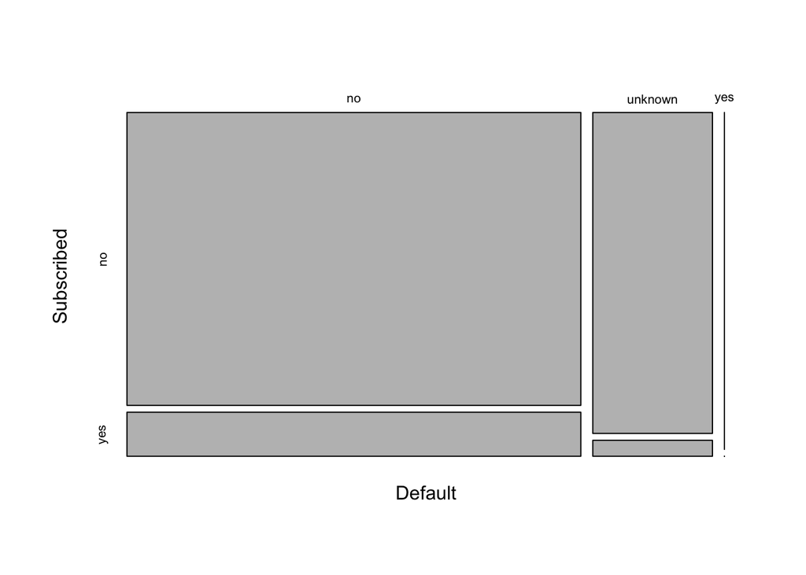

```r
mosaicplot(table(marketData$Default, marketData$Subscribed), main="", ylab="Subscribed", xlab="Default") #yes. a bit
```

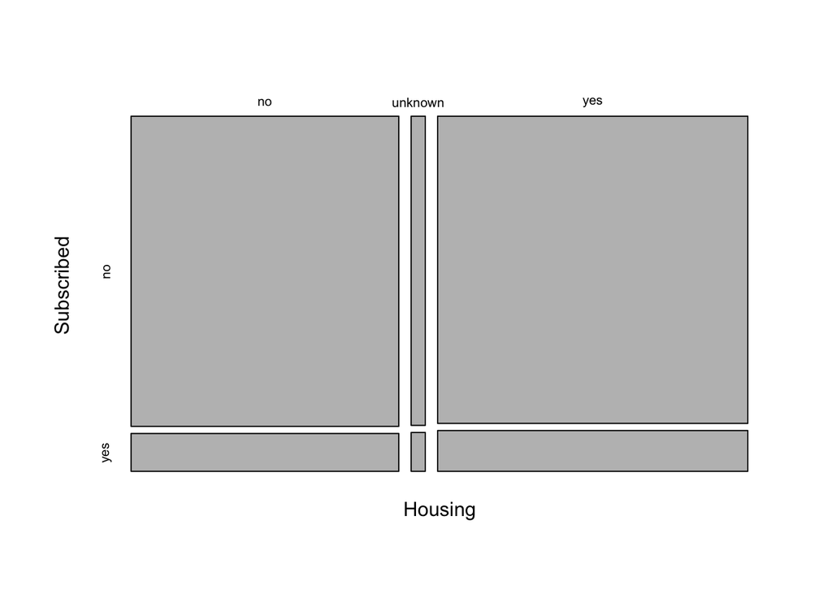

```r
mosaicplot(table(marketData$Housing, marketData$Subscribed), main="", ylab="Subscribed", xlab="Housing") #no
```

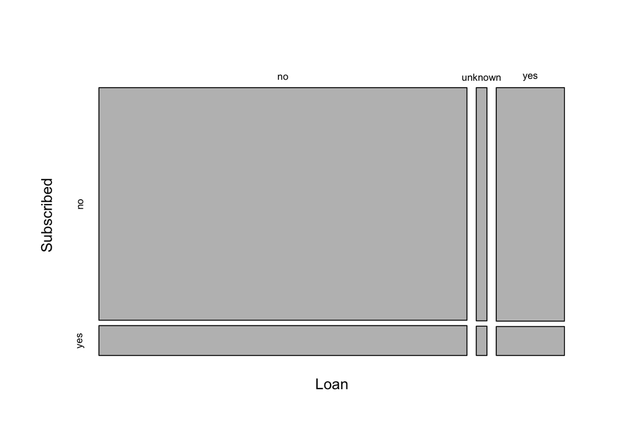

```r
mosaicplot(table(marketData$Loan, marketData$Subscribed), main="", ylab="Subscribed", xlab="Loan") #no
```

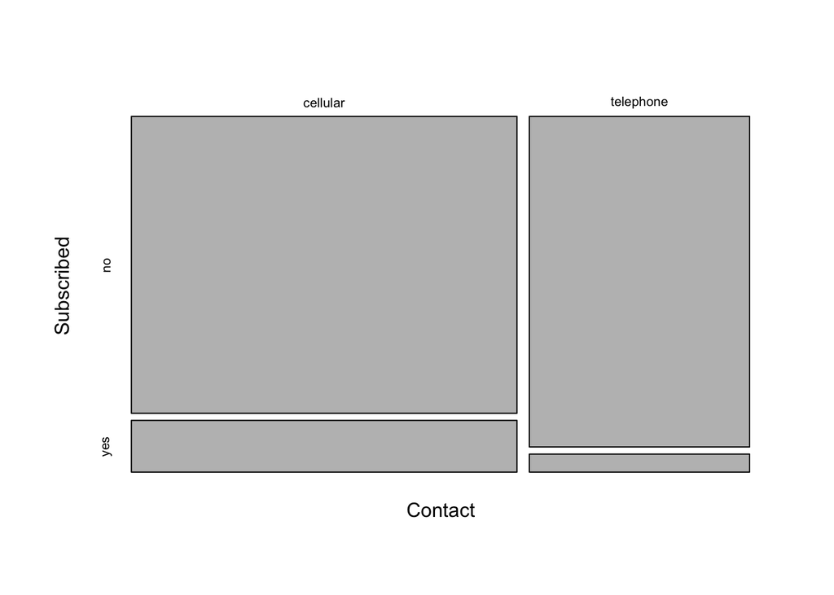

```r
mosaicplot(table(marketData$Contact, marketData$Subscribed), main="", ylab="Subscribed", xlab="Contact") #yes a bit
```

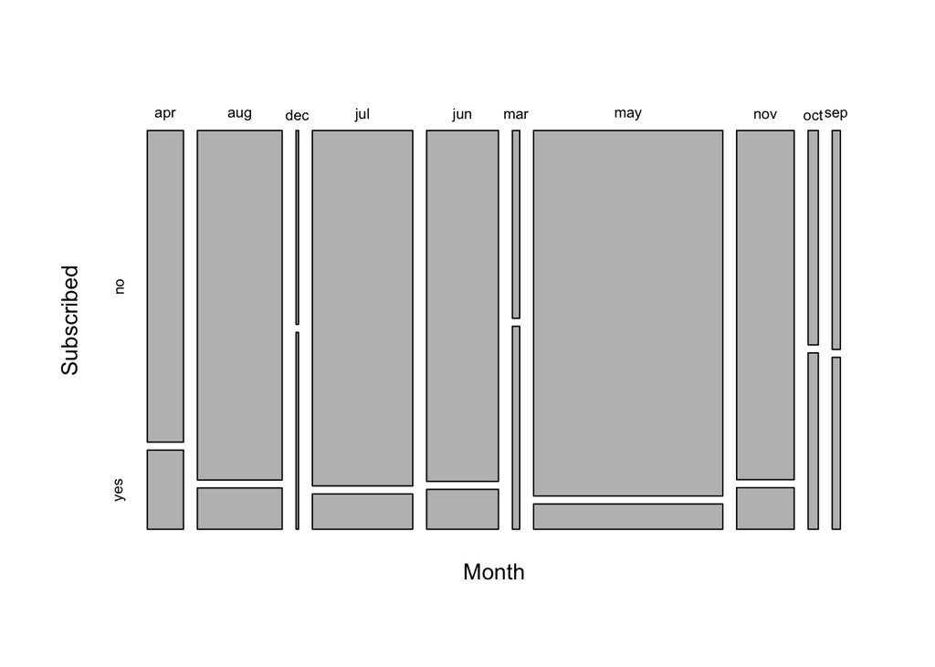

```r
mosaicplot(table(marketData$Month, marketData$Subscribed), main="", ylab="Subscribed", xlab="Month") #yes a lot
```

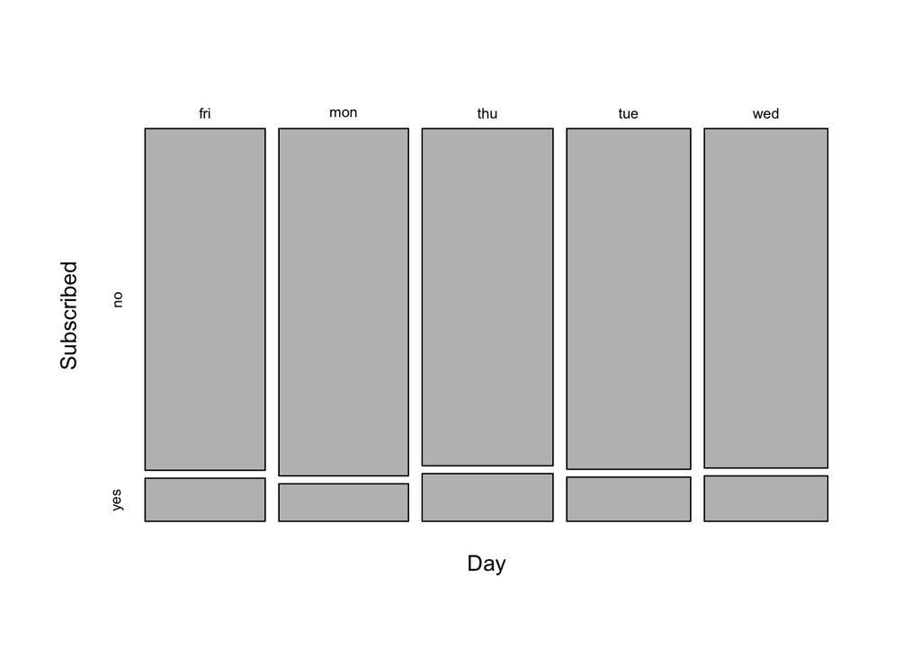

```r
mosaicplot(table(marketData$Day, marketData$Subscribed), main="", ylab="Subscribed", xlab="Day") #no
```

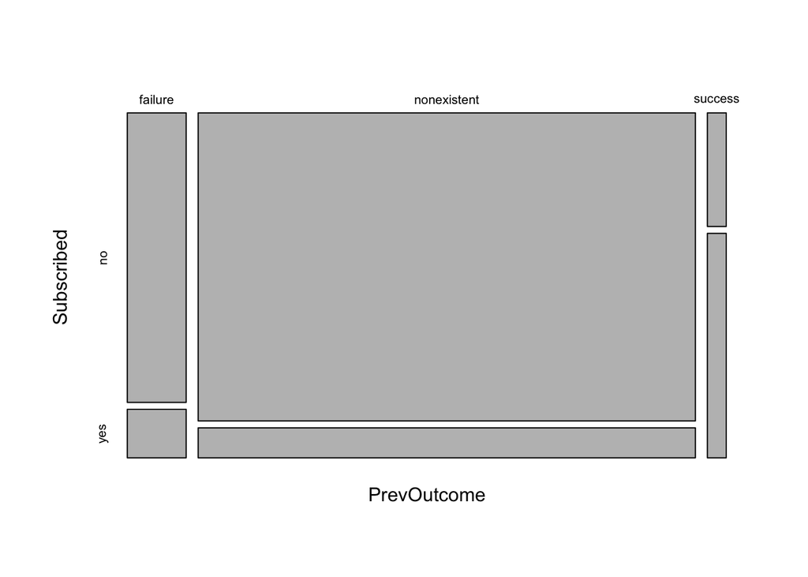

```r
mosaicplot(table(marketData$PrevOutcome, marketData$Subscribed), main="", ylab="Subscribed", xlab="PrevOutcome") #yes
```

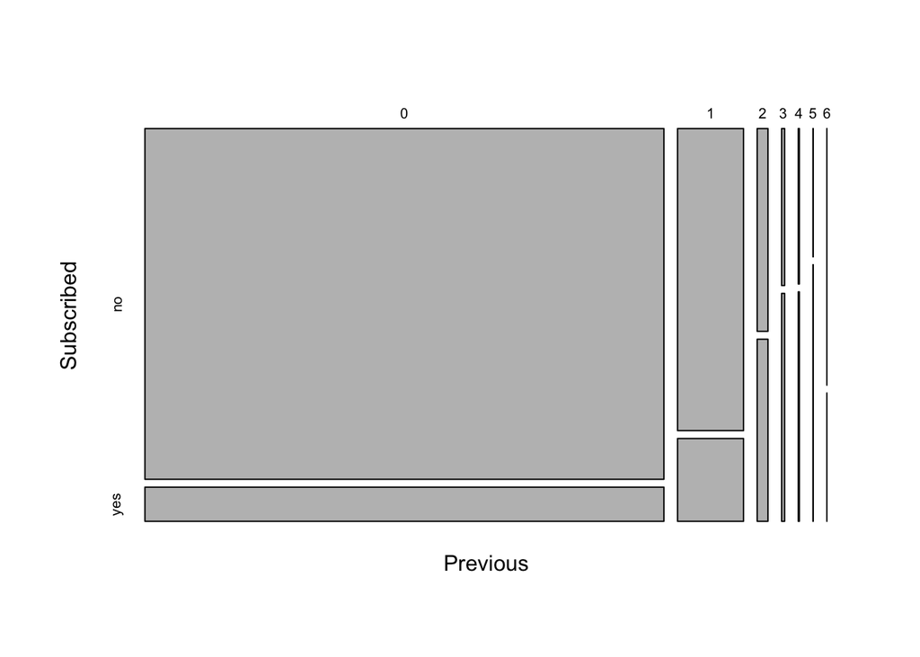

```r
mosaicplot(table(marketData$Previous, marketData$Subscribed), main="", ylab="Subscribed", xlab="Previous") #yes a lot
```

Based on the plot, Job, Month, Previous will have great effect on target value. Default, Contact, PrevOutcome may have some effect but a lot of non-existent value in PrevOutcome creates some concern. Marital, Education, Hosuing, Loan, Day does not matter.

Now, let plot the graph for continuous features.

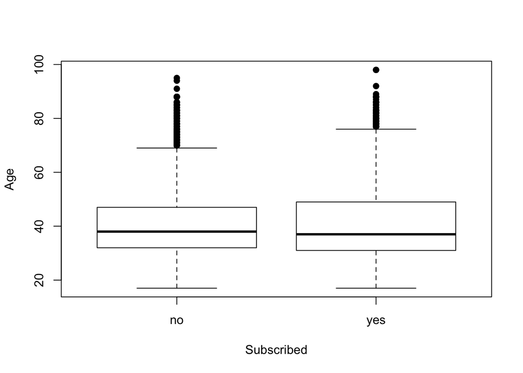

```r
boxplot(Age ~ Subscribed, data=marketData,xlab="Subscribed", ylab="Age", pch = 19)
```

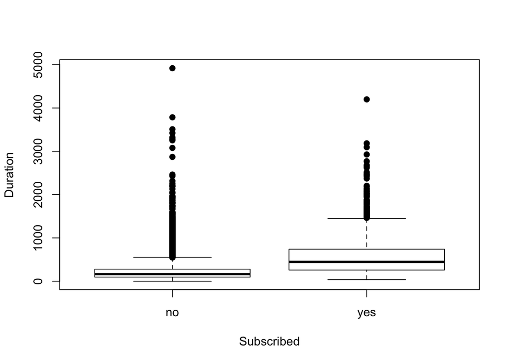

```r
boxplot(Duration~Subscribed,data=marketData, xlab="Subscribed", ylab="Duration", pch = 19) # yes
```

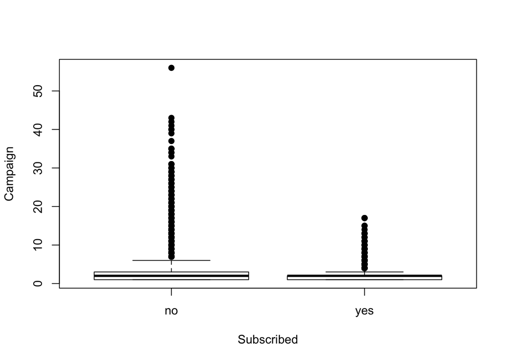

```r
boxplot(Campaign~Subscribed,data=marketData, xlab="Subscribed", ylab="Campaign", pch = 19) #yes
```

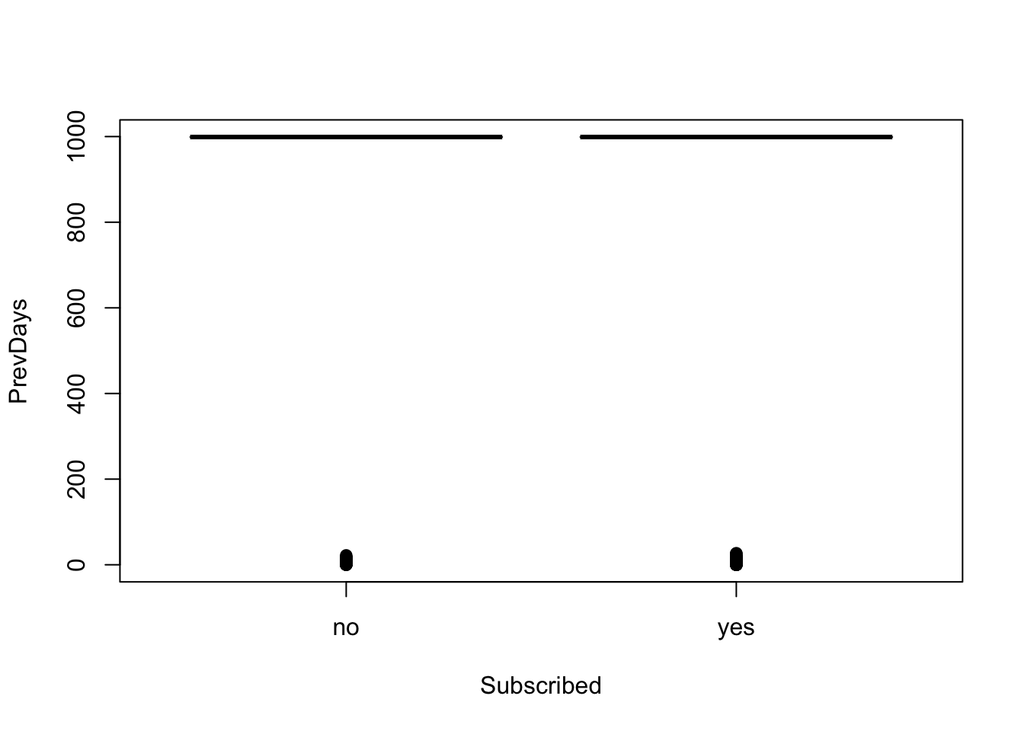

```r
boxplot(PrevDays~Subscribed,data=marketData, xlab="Subscribed", ylab="PrevDays", pch = 19) #no weired graph
```

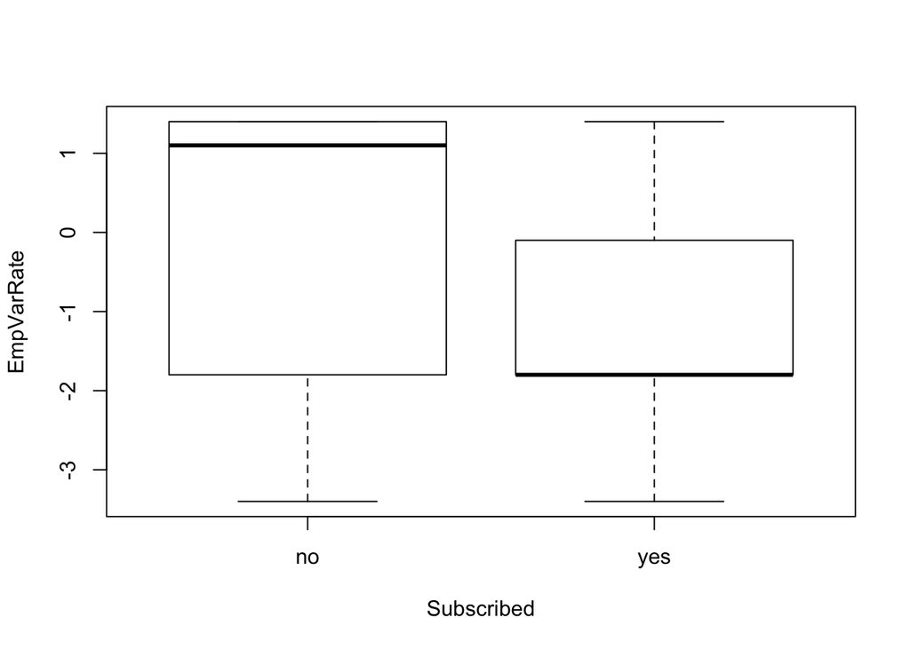

```r
boxplot(EmpVarRate~Subscribed,data=marketData, xlab="Subscribed", ylab="EmpVarRate", pch = 19) #no
```

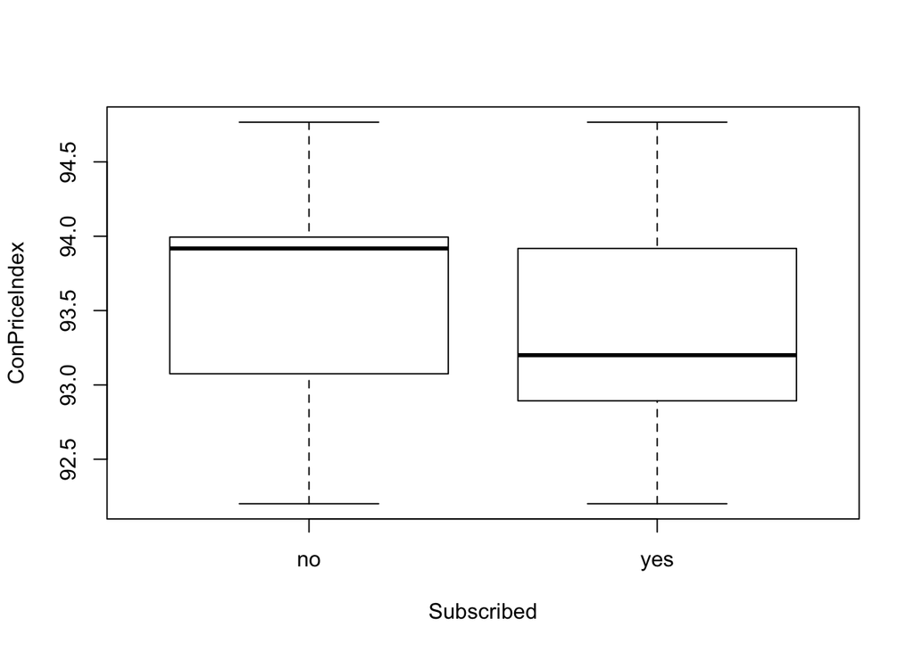

```r
boxplot(ConPriceIndex~Subscribed,data=marketData, xlab="Subscribed", ylab="ConPriceIndex", pch = 19) #no
```

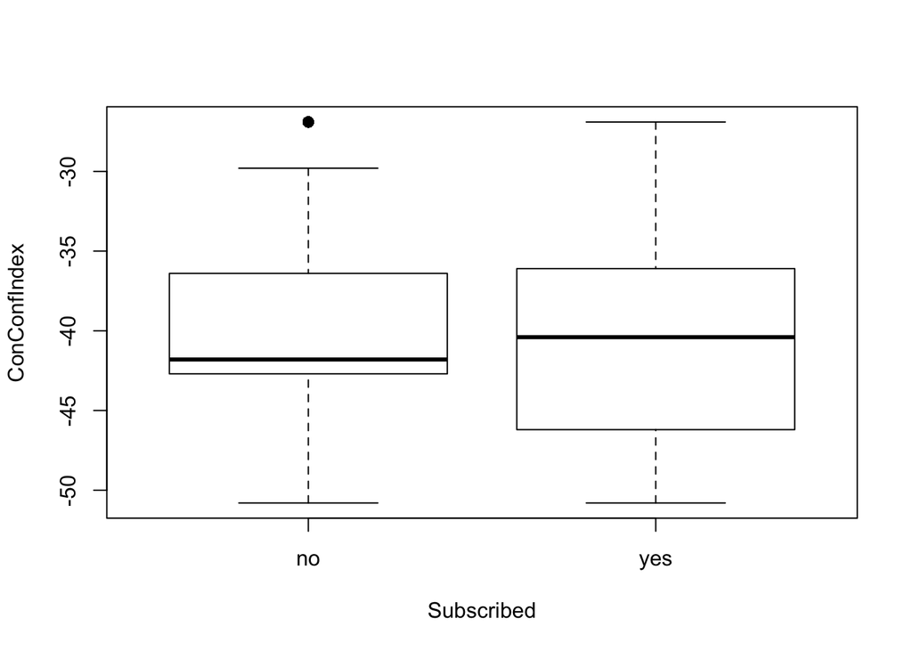

```r
boxplot(ConConfIndex~Subscribed,data=marketData, xlab="Subscribed", ylab="ConConfIndex", pch = 19) # a little bit
```

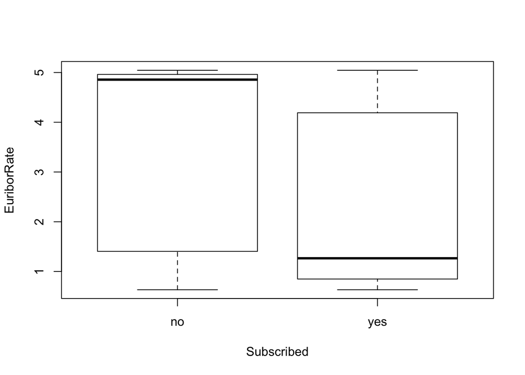

```r
boxplot(EuriborRate~Subscribed,data=marketData, xlab="Subscribed", ylab="EuriborRate", pch = 19) # no
```

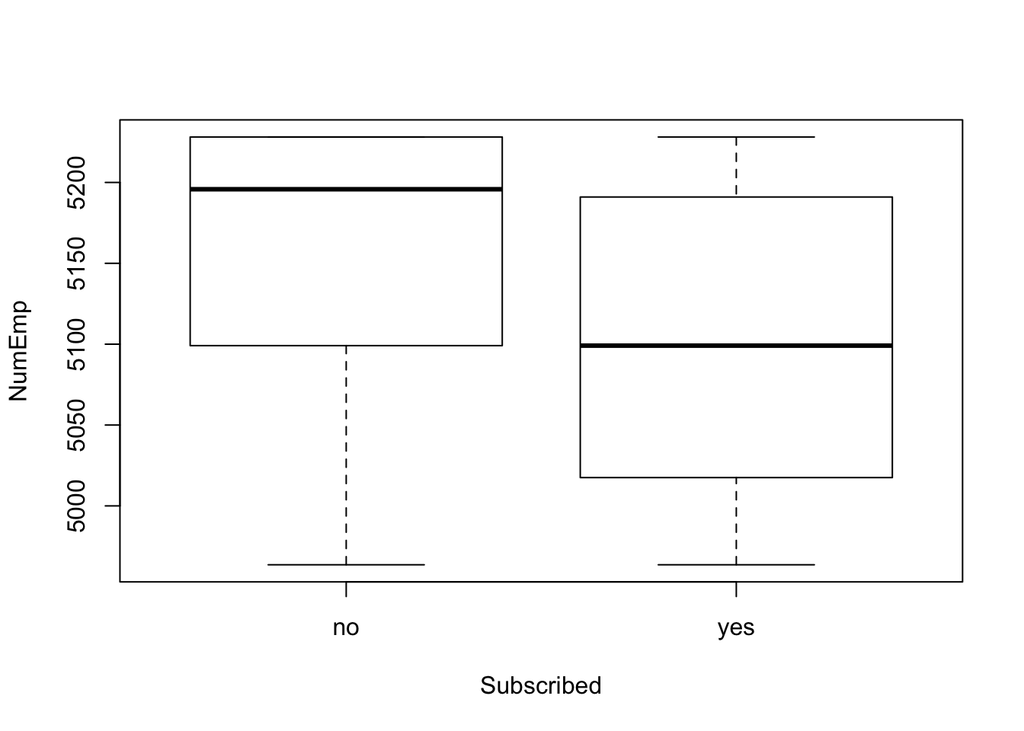

```r
boxplot(NumEmp~Subscribed,data=marketData, xlab="Subscribed", ylab="NumEmp", pch = 19) # no
```

**To conclude, Job, Month, Previous, Default, Contact, PrevOutcome, Duration and Campaign are important features affecting Subscribed.**

### Data Sampling

There is an high imbalance in original marketData. So, ROSE is used to rescale the data in order to avoid bias.

```r
library(ROSE)
```

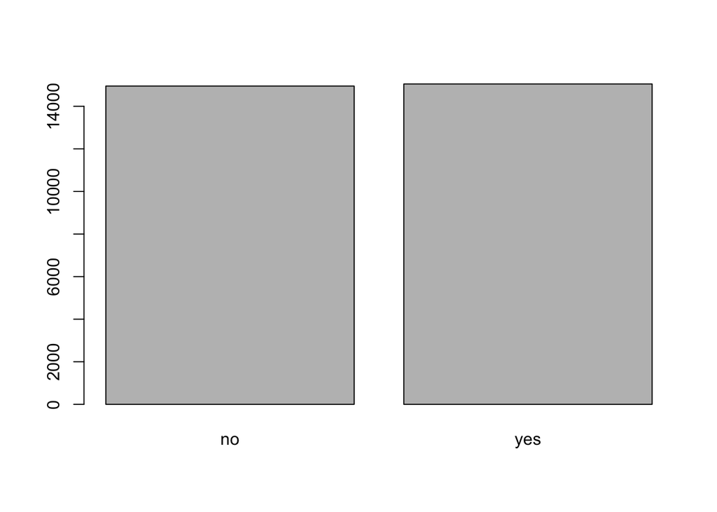

```r
newData <- ROSE(Subscribed~.,data=marketData)$data #With ROSE
plot(newData$Subscribed)
```

```r
summary(marketData$Subscribed)
```

```
##    no   yes
## 26603  3397
```

```r
summary(newData$Subscribed)
```

```
##    no   yes
## 14951 15049
```

Initially, there are over 26,000 of Nos and 3,397 of Yess. After ROSE sampling, both “yes” and “no” have around 15,000 elements.

Now, marketData is splited into train and test set by using 80:20 rule.

```r
train <- sample(nrow(newData), 0.8*nrow(newData), replace = FALSE)
marketTrain <- newData[train,]
marketValid <- newData[-train,]
summary(marketTrain)
```

```
##       Age                   Job           Marital             Education
##  Min.   : -4.639   admin      :6453   divorced: 2494   university  :7821
##  1st Qu.: 31.048   blue-collar:4477   married :13989   highschool  :5376
##  Median : 38.489   technician :3847   single  : 7480   basic9y     :3064
##  Mean   : 40.364   services   :2049   unknown :   37   professional:3035
##  3rd Qu.: 48.294   management :1791                    basic4y     :2368
##  Max.   :105.494   retired    :1580                    unknown     :1166
##                    (Other)    :3803                    (Other)     :1170
##     Default         Housing           Loan            Contact
##  no     :20232   no     :10636   no     :19780   cellular :17318
##  unknown: 3768   unknown:  591   unknown:  591   telephone: 6682
##  yes    :    0   yes    :12773   yes    : 3629
##
##
##
##
##      Month       Day          Duration         Campaign
##  may    :6605   fri:4570   Min.   :-579.5   Min.   :-3.4290
##  jul    :3818   mon:4660   1st Qu.: 126.3   1st Qu.: 0.8754
##  aug    :3499   thu:5201   Median : 280.3   Median : 1.8473
##  jun    :2865   tue:4749   Mean   : 385.0   Mean   : 2.3177
##  nov    :2386   wed:4820   3rd Qu.: 546.8   3rd Qu.: 3.1018
##  apr    :2028              Max.   :4271.2   Max.   :42.1443
##  (Other):2799
##     PrevDays         Previous             PrevOutcome      EmpVarRate
##  Min.   :-698.6   Min.   :-1.90224   failure    : 2747   Min.   :-6.0302
##  1st Qu.: 898.7   1st Qu.:-0.11493   nonexistent:18799   1st Qu.:-2.0329
##  Median : 986.9   Median : 0.08587   success    : 2454   Median :-0.4602
##  Mean   : 888.7   Mean   : 0.30642                       Mean   :-0.4931
##  3rd Qu.:1047.0   3rd Qu.: 0.48608                       3rd Qu.: 1.1746
##  Max.   :1745.4   Max.   : 6.32523                       Max.   : 4.1845
##
##  ConPriceIndex    ConConfIndex     EuriborRate         NumEmp
##  Min.   :91.14   Min.   :-59.46   Min.   :-2.439   Min.   :4833
##  1st Qu.:92.96   1st Qu.:-44.48   1st Qu.: 1.095   1st Qu.:5066
##  Median :93.49   Median :-40.67   Median : 3.051   Median :5151
##  Mean   :93.48   Mean   :-40.23   Mean   : 2.954   Mean   :5135
##  3rd Qu.:94.02   3rd Qu.:-36.10   3rd Qu.: 4.818   3rd Qu.:5214
##  Max.   :95.74   Max.   :-15.78   Max.   : 8.515   Max.   :5373
##
##  Subscribed
##  no :12003
##  yes:11997
##
##
##
##
##
```

```r
summary(marketValid)
```

```
##       Age                   Job           Marital            Education
##  Min.   :  1.647   admin      :1646   divorced: 670   university  :1980
##  1st Qu.: 30.813   blue-collar:1114   married :3452   highschool  :1378
##  Median : 38.491   technician : 979   single  :1864   basic9y     : 777
##  Mean   : 40.164   services   : 470   unknown :  14   professional: 723
##  3rd Qu.: 48.033   management : 446                   basic4y     : 561
##  Max.   :100.377   retired    : 356                   unknown     : 291
##                    (Other)    : 989                   (Other)     : 290
##     Default        Housing          Loan           Contact
##  no     :5071   no     :2641   no     :4973   cellular :4318
##  unknown: 929   unknown: 137   unknown: 137   telephone:1682
##  yes    :   0   yes    :3222   yes    : 890
##
##
##
##
##      Month       Day          Duration         Campaign
##  may    :1622   fri:1161   Min.   :-613.1   Min.   :-2.7412
##  jul    : 967   mon:1124   1st Qu.: 127.9   1st Qu.: 0.8854
##  aug    : 877   thu:1302   Median : 282.4   Median : 1.8386
##  jun    : 721   tue:1193   Mean   : 393.2   Mean   : 2.3077
##  nov    : 592   wed:1220   3rd Qu.: 555.0   3rd Qu.: 3.1346
##  apr    : 537              Max.   :4955.7   Max.   :37.5032
##  (Other): 684
##     PrevDays         Previous             PrevOutcome     EmpVarRate
##  Min.   :-647.7   Min.   :-1.53390   failure    : 691   Min.   :-5.9995
##  1st Qu.: 896.9   1st Qu.:-0.11822   nonexistent:4690   1st Qu.:-2.0501
##  Median : 985.9   Median : 0.08151   success    : 619   Median :-0.3804
##  Mean   : 885.4   Mean   : 0.31007                      Mean   :-0.4757
##  3rd Qu.:1047.1   3rd Qu.: 0.49941                      3rd Qu.: 1.1973
##  Max.   :1657.4   Max.   : 6.33455                      Max.   : 3.9781
##
##  ConPriceIndex    ConConfIndex     EuriborRate         NumEmp
##  Min.   :91.26   Min.   :-59.10   Min.   :-2.659   Min.   :4848
##  1st Qu.:92.95   1st Qu.:-44.46   1st Qu.: 1.105   1st Qu.:5064
##  Median :93.48   Median :-40.60   Median : 3.175   Median :5152
##  Mean   :93.47   Mean   :-40.18   Mean   : 2.978   Mean   :5136
##  3rd Qu.:94.02   3rd Qu.:-36.16   3rd Qu.: 4.853   3rd Qu.:5214
##  Max.   :95.46   Max.   :-19.17   Max.   : 7.521   Max.   :5403
##
##  Subscribed
##  no :2948
##  yes:3052
##
##
##
##
##
```

Both training and validation sets have nearly equal number of “yes” and “no”. Therefore, data is well prepared to start training.

### Decision Tree with Personal Profile and Financial Profile

Simple Decision Tree is made to observe which variables are important.

```r
library("tree")
library(randomForest)
```

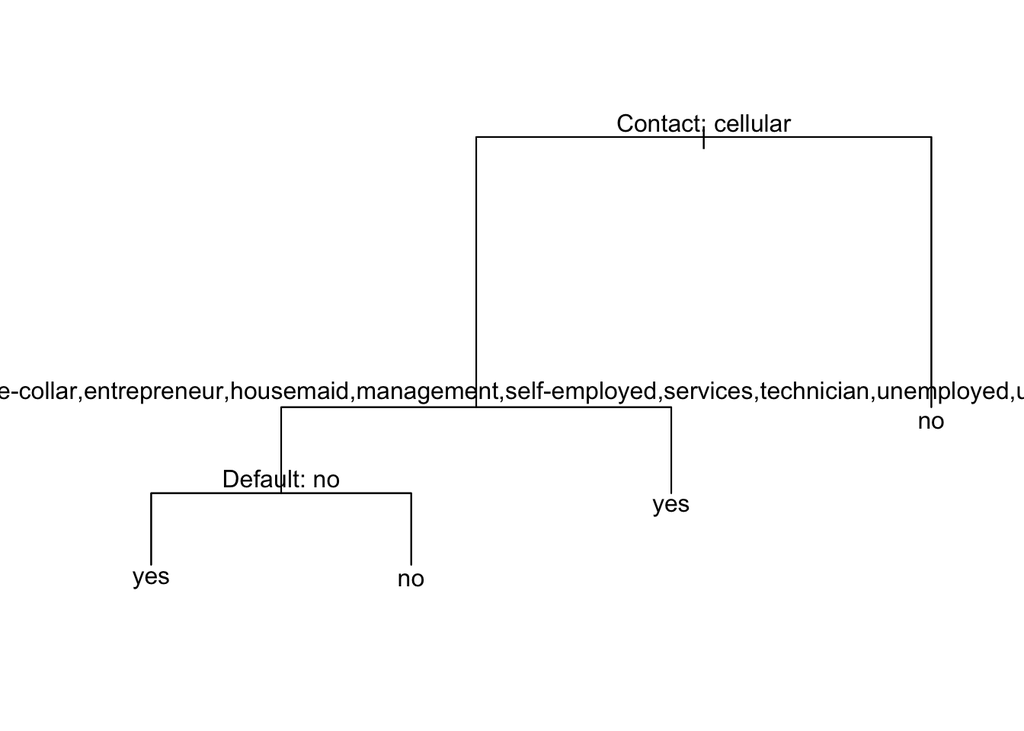

```r
treeFit <- tree(Subscribed ~ Age+Job+Marital+Education+Default+Housing+Loan+Contact, data = marketTrain)
plot(treeFit)
text(treeFit, pretty = FALSE)
```

```r
summary(treeFit)
```

```
##
## Classification tree:
## tree(formula = Subscribed ~ Age + Job + Marital + Education +
##     Default + Housing + Loan + Contact, data = marketTrain)
## Variables actually used in tree construction:
## [1] "Contact" "Job"     "Default"
## Number of terminal nodes:  4
## Residual mean deviance:  1.284 = 30810 / 24000
## Misclassification error rate: 0.3608 = 8660 / 24000
```

```r
treeFit
```

```
## node), split, n, deviance, yval, (yprob)
##       * denotes terminal node
##
## 1) root 24000 33270 no ( 0.5001 0.4999 )
##   2) Contact: cellular 17318 23580 yes ( 0.4220 0.5780 )
##     4) Job: admin,blue-collar,entrepreneur,housemaid,management,self-employed,services,technician,unemployed,unknown 15272 21030 yes ( 0.4513 0.5487 )
##       8) Default: no 13395 18230 yes ( 0.4208 0.5792 ) *
##       9) Default: unknown 1877  2383 no ( 0.6692 0.3308 ) *
##     5) Job: retired,student 2046  2064 yes ( 0.2028 0.7972 ) *
##   3) Contact: telephone 6682  8134 no ( 0.7026 0.2974 ) *
```

```r
predTrain <- predict(treeFit, marketTrain, type = "class")  # prediction on train set
mean(predTrain == marketTrain$Subscribed)                       # classification accuracy
```

```
## [1] 0.6391667
```

```r
predValid <- predict(treeFit, marketValid, type = "class")  # prediction on validation set
mean(predValid == marketValid$Subscribed)                       # classification accuracy
```

```
## [1] 0.6431667
```

“Contact”,“Default” “Job” are the only variables used in decision tree, which means they are important variables.

It’s classification accuracy in both test set and validation set is observed to be quite low.

Then, optimised random forest is used to get the best possible model. It is observed that choosing 3 as variable for split will give the optimal result.

```r
trials <- 8               # Number of trials for mtry
nTree <- 500              # Fixing the value of ntree

oobError <- double(trials)
for (mt in 1:trials) {
  rfFit <- randomForest(Subscribed ~ Age+Job+Marital+Education+Default+Housing+Loan+Contact, data = marketTrain, ntree = nTree, mtry = mt)
  oobError[mt] <- rfFit$err.rate[nTree,1]   # OOB MSE after fitting all trees
  cat("Experiment completed with mtry = ", mt, "\n")
}
```

```
## Experiment completed with mtry =  1
## Experiment completed with mtry =  2
## Experiment completed with mtry =  3
## Experiment completed with mtry =  4
## Experiment completed with mtry =  5
## Experiment completed with mtry =  6
## Experiment completed with mtry =  7
## Experiment completed with mtry =  8
```

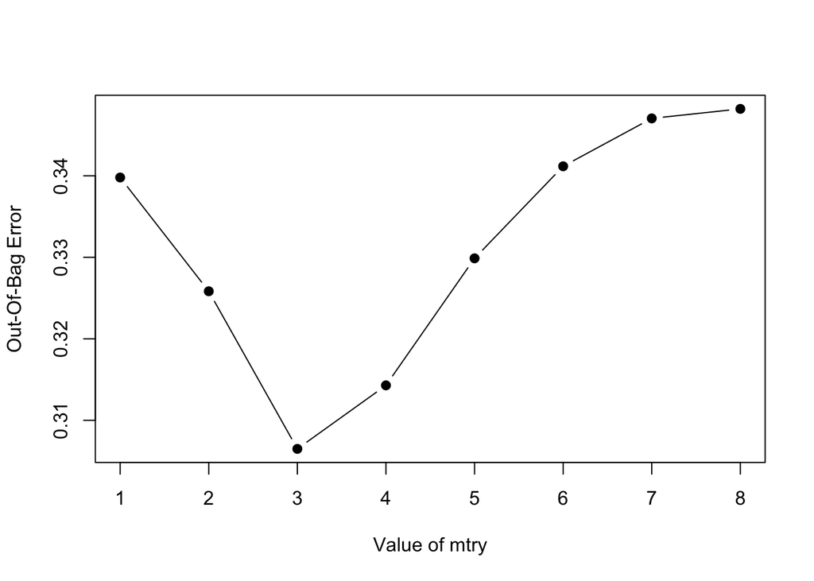

```r
plot(1:trials, oobError, pch=19, type="b",
     xlab = "Value of mtry", ylab = "Out-Of-Bag Error")
```

```r
rfFit <- randomForest(Subscribed ~ Age+Job+Marital+Education+Default+Housing+Loan+Contact, data = marketTrain,
                      ntree = 500, mtry = 3,
                      na.action = na.action(marketTrain),
                      importance = TRUE)
rfFit
```

```
##
## Call:
##  randomForest(formula = Subscribed ~ Age + Job + Marital + Education +      Default + Housing + Loan + Contact, data = marketTrain, ntree = 500,      mtry = 3, importance = TRUE, na.action = na.action(marketTrain))
##                Type of random forest: classification
##                      Number of trees: 500
## No. of variables tried at each split: 3
##
##         OOB estimate of  error rate: 30.73%
## Confusion matrix:
##       no  yes class.error
## no  7773 4230   0.3524119
## yes 3146 8851   0.2622322
```

```r
predTrain <- predict(rfFit, marketTrain, type = "class")  # prediction on train set
mean(predTrain == marketTrain$Subscribed)                       # classification accuracy
```

```
## [1] 0.7782917
```

```r
predValid <- predict(rfFit, marketValid, type = "class")  # prediction on validation set
mean(predValid == marketValid$Subscribed)
```

```
## [1] 0.685
```

```r
importance(rfFit)        # importance of the variables in the model (values)
```

```
##                 no       yes MeanDecreaseAccuracy MeanDecreaseGini
## Age       96.95081  46.64157            110.31607        2290.7231
## Job       34.75191  86.77407            130.43927         886.7328
## Marital   35.97879  68.82055             91.70160         281.6060
## Education 15.84098  96.76268            120.41471         584.8618
## Default   23.88507 186.82748            159.63528         333.8317
## Housing   24.74696  79.67212             73.42856         231.9788
## Loan      18.74260  80.74057             74.84218         200.8011
## Contact   87.43253 211.22876            199.89334         653.7530
```

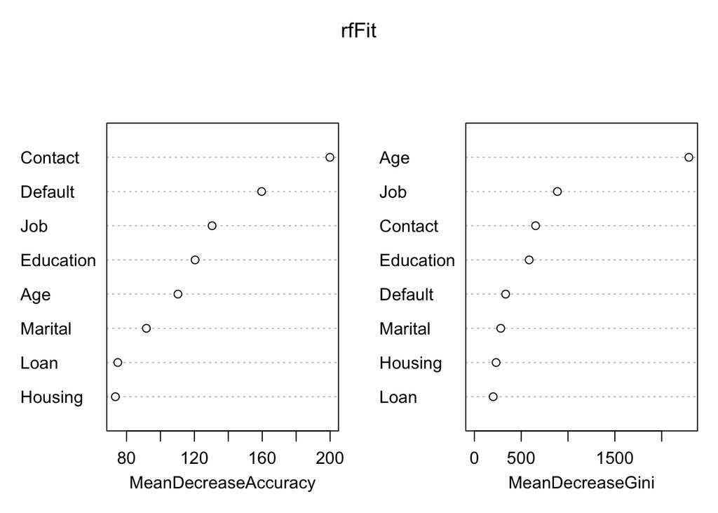

```r
varImpPlot(rfFit)        # importance of the variables in the model (visual)
```

So, based on the result, Contact, Default and Job are three most important features for Personal+Financial. It is also matched with our initial intuition and single tree result. Prediction accuracy is around 78% in both training set and 70% in validation set.

Based on the tree, we should target those people who has cellular phone since they are more likely to subscribe. We can target person with any type of jobs if we know exactly whether they have credit in default or not.

These are the predictions made by using this model. In prediction data, Education and Default does not have same number of categorical types as in training data. So, we need to balance it before doing prediction

There is a difference in level in prediction data compared to old data. So, we need to do some leveling before we can do prediction.

```r
str(predData)
```

```
## 'data.frame':    1000 obs. of  20 variables:
##  $ Age          : int  29 25 37 31 37 49 48 52 35 34 ...
##  $ Job          : Factor w/ 12 levels "admin","blue-collar",..: 3 2 2 10 1 4 2 10 5 5 ...
##  $ Marital      : Factor w/ 4 levels "divorced","married",..: 2 3 2 2 2 2 2 2 2 2 ...
##  $ Education    : Factor w/ 7 levels "basic4y","basic6y",..: 2 3 5 6 6 5 3 5 6 6 ...
##  $ Default      : Factor w/ 2 levels "no","unknown": 1 1 1 1 1 1 1 1 1 1 ...
##  $ Housing      : Factor w/ 3 levels "no","unknown",..: 1 1 1 1 1 3 1 1 3 1 ...
##  $ Loan         : Factor w/ 3 levels "no","unknown",..: 1 1 1 1 1 1 1 1 1 1 ...
##  $ Contact      : Factor w/ 2 levels "cellular","telephone": 2 1 2 1 2 2 1 1 1 2 ...
##  $ Month        : Factor w/ 10 levels "apr","aug","dec",..: 7 7 5 2 5 4 7 4 1 7 ...
##  $ Day          : Factor w/ 5 levels "fri","mon","thu",..: 1 1 3 1 2 3 3 1 3 3 ...
##  $ Duration     : int  217 299 11 168 85 645 214 221 584 200 ...
##  $ Campaign     : int  2 3 7 1 8 2 1 2 1 2 ...
##  $ PrevDays     : int  999 999 999 999 999 999 999 999 999 999 ...
##  $ Previous     : int  0 0 0 0 0 0 1 0 0 0 ...
##  $ PrevOutcome  : Factor w/ 3 levels "failure","nonexistent",..: 2 2 2 2 2 2 1 2 2 2 ...
##  $ EmpVarRate   : num  1.1 -1.8 1.4 1.4 1.4 1.4 -1.8 1.4 -1.8 1.1 ...
##  $ ConPriceIndex: num  94 92.9 94.5 93.4 94.5 ...
##  $ ConConfIndex : num  -36.4 -46.2 -41.8 -36.1 -41.8 -42.7 -46.2 -42.7 -47.1 -36.4 ...
##  $ EuriborRate  : num  4.86 1.31 4.96 4.96 4.87 ...
##  $ NumEmp       : num  5191 5099 5228 5228 5228 ...
```

```r
str(newData)
```

```
## 'data.frame':    30000 obs. of  21 variables:
##  $ Age          : num  33.3 38.6 25.3 46.9 49.7 ...
##  $ Job          : Factor w/ 12 levels "admin","blue-collar",..: 8 8 2 5 10 7 3 1 8 1 ...
##  $ Marital      : Factor w/ 4 levels "divorced","married",..: 1 2 3 2 2 2 2 2 3 2 ...
##  $ Education    : Factor w/ 8 levels "basic4y","basic6y",..: 4 4 3 2 3 7 8 7 4 7 ...
##  $ Default      : Factor w/ 3 levels "no","unknown",..: 2 1 2 1 1 1 2 1 2 1 ...
##  $ Housing      : Factor w/ 3 levels "no","unknown",..: 3 3 3 1 1 3 3 1 1 1 ...
##  $ Loan         : Factor w/ 3 levels "no","unknown",..: 1 1 1 1 1 1 1 1 1 1 ...
##  $ Contact      : Factor w/ 2 levels "cellular","telephone": 2 2 2 2 1 2 1 2 2 1 ...
##  $ Month        : Factor w/ 10 levels "apr","aug","dec",..: 5 5 7 5 4 4 4 5 7 2 ...
##  $ Day          : Factor w/ 5 levels "fri","mon","thu",..: 3 1 3 5 3 3 2 4 1 5 ...
##  $ Duration     : num  107.8 -38.4 148.3 170.8 204.5 ...
##  $ Campaign     : num  2.92 3.19 1.94 1.74 7.14 ...
##  $ PrevDays     : num  1065 1040 1007 1017 1017 ...
##  $ Previous     : num  -0.0162 0.0628 0.0705 -0.0663 -0.1629 ...
##  $ PrevOutcome  : Factor w/ 3 levels "failure","nonexistent",..: 2 2 2 2 2 2 2 2 2 2 ...
##  $ EmpVarRate   : num  1.44 2.86 2.35 2.05 2.47 ...
##  $ ConPriceIndex: num  94.3 94.5 94.1 94.2 94 ...
##  $ ConConfIndex : num  -43.1 -41.6 -36.2 -42.9 -41.6 ...
##  $ EuriborRate  : num  4.72 5.05 5.45 4.72 5.1 ...
##  $ NumEmp       : num  5247 5176 5174 5216 5231 ...
##  $ Subscribed   : Factor w/ 2 levels "no","yes": 1 1 1 1 1 1 1 1 1 1 ...
```

```r
levels(predData$Education) <- levels(marketTrain$Education)
levels(predData$Default) <- levels(marketTrain$Default)
prediction <- predict(rfFit,predData,type="class")
summary(prediction)
```

```
##  no yes
## 648 352
```

### Decision Tree with Personal Profile, Finanical Profile and Campaign Data

All the Prcedure are same as the first model except for the fact that this model has more features than the first one.

Simple Decision Tree is made to observe which variables are important

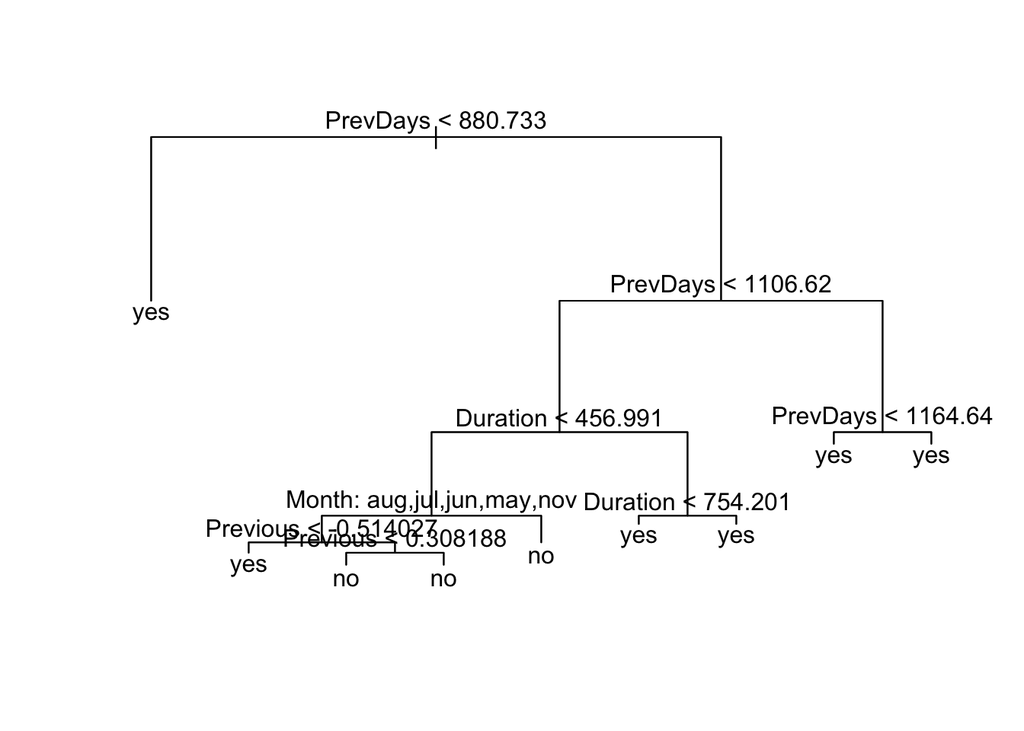

```r
treeFit <- tree(Subscribed ~ Age+Job+Marital+Education+Default+Housing+Loan+Contact+Month+Day+Duration+Campaign+PrevDays+Previous+PrevOutcome, data = marketTrain)
plot(treeFit)
text(treeFit, pretty = FALSE)
```

```r
summary(treeFit)
```

```
##
## Classification tree:
## tree(formula = Subscribed ~ Age + Job + Marital + Education +
##     Default + Housing + Loan + Contact + Month + Day + Duration +
##     Campaign + PrevDays + Previous + PrevOutcome, data = marketTrain)
## Variables actually used in tree construction:
## [1] "PrevDays" "Duration" "Month"    "Previous"
## Number of terminal nodes:  9
## Residual mean deviance:  0.6353 = 15240 / 23990
## Misclassification error rate: 0.137 = 3289 / 24000
```

```r
treeFit
```

```
## node), split, n, deviance, yval, (yprob)
##       * denotes terminal node
##
##  1) root 24000 33270.00 no ( 0.500125 0.499875 )
##    2) PrevDays < 880.733 5530  2394.00 yes ( 0.056239 0.943761 ) *
##    3) PrevDays > 880.733 18470 24280.00 no ( 0.633027 0.366973 )
##      6) PrevDays < 1106.62 15313 17290.00 no ( 0.747861 0.252139 )
##       12) Duration < 456.991 11874  9477.00 no ( 0.863231 0.136769 )
##         24) Month: aug,jul,jun,may,nov 10346  6301.00 no ( 0.909144 0.090856 )
##           48) Previous < -0.514027 116    85.44 yes ( 0.120690 0.879310 ) *
##           49) Previous > -0.514027 10230  5799.00 no ( 0.918084 0.081916 )
##             98) Previous < 0.308188 8716  3619.00 no ( 0.946879 0.053121 ) *
##             99) Previous > 0.308188 1514  1695.00 no ( 0.752312 0.247688 ) *
##         25) Month: apr,dec,mar,oct,sep 1528  2101.00 no ( 0.552356 0.447644 ) *
##       13) Duration > 456.991 3439  4451.00 yes ( 0.349520 0.650480 )
##         26) Duration < 754.201 1938  2683.00 yes ( 0.477296 0.522704 ) *
##         27) Duration > 754.201 1501  1436.00 yes ( 0.184544 0.815456 ) *
##      7) PrevDays > 1106.62 3157  1698.00 yes ( 0.076022 0.923978 )
##       14) PrevDays < 1164.64 1097  1135.00 yes ( 0.212397 0.787603 ) *
##       15) PrevDays > 1164.64 2060    93.56 yes ( 0.003398 0.996602 ) *
```

```r
predTrain <- predict(treeFit, marketTrain, type = "class")  # prediction on train set
mean(predTrain == marketTrain$Subscribed)                       # classification accuracy
```

```
## [1] 0.8629583
```

```r
predValid <- predict(treeFit, marketValid, type = "class")  # prediction on validation set
mean(predValid == marketValid$Subscribed)                       # classification accuracy
```

```
## [1] 0.851
```

“PrevDays”,“Duration”,“Month”,“Previous” are the only variables used in decision tree, which means they are important variables. It is observed that previous important features Contact, Default and Job are not important compared to new additional features.

It’s classification accuracy in both test set and validation set becomes higher than pervious optimal random forest which means that Campaign data is more important that personal and finanical data.